# Practical Machine Learning Project

Wouter van Amsterdam

7 September 2016

## Introduction

The problem defined for this project is how to classify proper weight lifting with on-body sensors See also: http://groupware.les.inf.puc-rio.br/har

This markdown document will guide you through the process of model building and validation, and show the acheived results

NB I will use the data.table package for my data handling, which uses a syntax for subsetting that’s a bit different from data.frames See: https://cran.r-project.org/web/packages/data.table/vignettes/datatable-intro.pdf

## Downloading and importing data

### Download data

```r
url <- "https://d396qusza40orc.cloudfront.net/predmachlearn/pml-training.csv"
download.file(url, destfile = 'data/pml-training.csv')
url2 <- "https://d396qusza40orc.cloudfront.net/predmachlearn/pml-testing.csv"
download.file(url2, destfile = 'data/pml-testing.csv')
```

### Import data into R

```r
library(data.table)
training <- data.table(read.csv("data/pml-training.csv", header = T))
problems  <- data.table(read.csv("data/pml-testing.csv", header = T))
```

## Data exploration and curation

First we need to get a feel for the training data.

Look at head of the data and for missing data

```r
library(data.table)
head(training)
colSums(is.na(training))
```

[output not shown]

Take a better look at the timestamps. CVTD_timestamp is the date and time, raw_timestamp_part_2 probably contains the millisecond information, and raw_timestamp_part_1 the second information (last two digits).

```r
training[, head(cbind(raw_timestamp_part_1, raw_timestamp_part_2,
                      as.character(cvtd_timestamp)), 30)]
```

```
##       raw_timestamp_part_1 raw_timestamp_part_2
##  [1,] "1323084231"         "788290"             "05/12/2011 11:23"
##  [2,] "1323084231"         "808298"             "05/12/2011 11:23"
##  [3,] "1323084231"         "820366"             "05/12/2011 11:23"
##  [4,] "1323084232"         "120339"             "05/12/2011 11:23"
##  [5,] "1323084232"         "196328"             "05/12/2011 11:23"
##  [6,] "1323084232"         "304277"             "05/12/2011 11:23"
##  [7,] "1323084232"         "368296"             "05/12/2011 11:23"
##  [8,] "1323084232"         "440390"             "05/12/2011 11:23"
##  [9,] "1323084232"         "484323"             "05/12/2011 11:23"
## [10,] "1323084232"         "484434"             "05/12/2011 11:23"
## [11,] "1323084232"         "500302"             "05/12/2011 11:23"
## [12,] "1323084232"         "528316"             "05/12/2011 11:23"
## [13,] "1323084232"         "560359"             "05/12/2011 11:23"
## [14,] "1323084232"         "576390"             "05/12/2011 11:23"
```

[output cut: 16 more lines]

When pasted together, they give unique identifiers to each row, which are separated by time.

```r
training[, date_time:=lubridate::dmy_hm(cvtd_timestamp)]
training[, time_id:=as.numeric(paste0(raw_timestamp_part_1, ".",
                                      raw_timestamp_part_2))]
```

This can be used for plotting to see what the subjects are doing on consequtive timepoints in the training set.

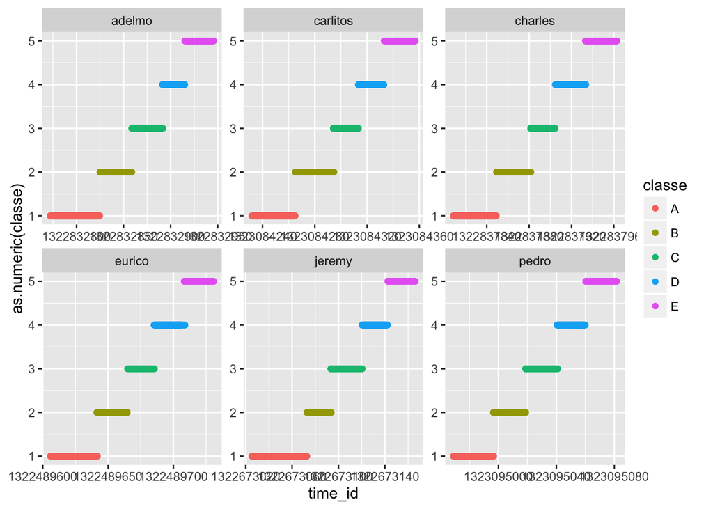

```r
library(ggplot2)
ggplot(training) + aes(x = time_id, y = as.numeric(classe), col = classe) +
        geom_point() + facet_wrap(~user_name, scales = "free")
```

So what is going on in the test set? For each user, only a few lines are present. All column names in are present in training, except for ‘problem_id’. Some columns are completely empty, these won’t be very helpfull with classification. They appear to be aggregated versions of other varibales. We will throw them out.

```r
problems[, table(user_name)]
```

```
## user_name
##   adelmo carlitos  charles   eurico   jeremy    pedro
##        1        3        1        4        8        3
```

```r
setdiff(colnames(problems), colnames(training))
```

```
## [1] "problem_id"
```

```r
problems[, problem_id]
```

```
##  [1]  1  2  3  4  5  6  7  8  9 10 11 12 13 14 15 16 17 18 19 20
```

```r
empty_vars <- names(problems)[colSums(is.na(problems)) == nrow(problems)]
empty_vars
```

```
##   [1] "kurtosis_roll_belt"       "kurtosis_picth_belt"
##   [3] "kurtosis_yaw_belt"        "skewness_roll_belt"
##   [5] "skewness_roll_belt.1"     "skewness_yaw_belt"
##   [7] "max_roll_belt"            "max_picth_belt"
##   [9] "max_yaw_belt"             "min_roll_belt"
##  [11] "min_pitch_belt"           "min_yaw_belt"
##  [13] "amplitude_roll_belt"      "amplitude_pitch_belt"
##  [15] "amplitude_yaw_belt"       "var_total_accel_belt"
##  [17] "avg_roll_belt"            "stddev_roll_belt"
##  [19] "var_roll_belt"            "avg_pitch_belt"
##  [21] "stddev_pitch_belt"        "var_pitch_belt"
##  [23] "avg_yaw_belt"             "stddev_yaw_belt"
##  [25] "var_yaw_belt"             "var_accel_arm"
##  [27] "avg_roll_arm"             "stddev_roll_arm"
##  [29] "var_roll_arm"             "avg_pitch_arm"
```

[output cut: 35 more lines]

```r
training <- training[, .SD, .SDcols = !names(training) %in% empty_vars]
problems  <- problems[, .SD, .SDcols = !names(problems) %in% empty_vars]
```

Now that we’ve kicked out the empty variables, let’s look at the 60 remaining variables. ‘X’ in this dataset is just a rownumber, and can be excluded. A few variables make no sense to include in the modeling.

```r
training <- training[, .SD, .SDcols = -c("X")]
problems <- problems[, .SD, .SDcols = -c("X")]
ex_vars <- c("user_name", "raw_timestamp_part_1", "raw_timestamp_part_2",
             "cvtd_timestamp", "new_window", "num_window",
             "time_id", "date_time")
```

## Modeling

Let’s start modeling

```r
library(caret)
set.seed(57)
inTrain <- createDataPartition(training$classe, p = .6, list = F)
tr <- training[inTrain, .SD, .SDcols = -ex_vars]
te <- training[-inTrain,.SD, .SDcols = -ex_vars]
dim(tr); dim(te)
```

```
## [1] 11776    53
```

```
## [1] 7846   53
```

```r
fit_gbm <- train(classe~., data = tr,
                 method = 'gbm',
                 verbose = F)
confusionMatrix(predict(fit_gbm, newdata = te), reference = te$classe)
```

```
## Confusion Matrix and Statistics
##
##           Reference
## Prediction    A    B    C    D    E
##          A 2191   44    0    0    3
##          B   23 1430   38    2   14
##          C    4   42 1306   46   11
##          D   11    2   17 1231   21
##          E    3    0    7    7 1393
##
## Overall Statistics
##
##                Accuracy : 0.9624
##                  95% CI : (0.958, 0.9665)
##     No Information Rate : 0.2845
##     P-Value [Acc > NIR] : < 2.2e-16
##
##                   Kappa : 0.9524
##  Mcnemar's Test P-Value : 1.321e-08
##
## Statistics by Class:
##
##                      Class: A Class: B Class: C Class: D Class: E
## Sensitivity            0.9816   0.9420   0.9547   0.9572   0.9660
## Specificity            0.9916   0.9878   0.9841   0.9922   0.9973
## Pos Pred Value         0.9790   0.9489   0.9269   0.9602   0.9879
## Neg Pred Value         0.9927   0.9861   0.9904   0.9916   0.9924
## Prevalence             0.2845   0.1935   0.1744   0.1639   0.1838
## Detection Rate         0.2793   0.1823   0.1665   0.1569   0.1775
## Detection Prevalence   0.2852   0.1921   0.1796   0.1634   0.1797
## Balanced Accuracy      0.9866   0.9649   0.9694   0.9747   0.9817
```

Try a different model: random forest with 5-fold cross validation. Also using multi-threading to speed things up. Still it took 21 minutes.

```r
library(caret)
library(doMC)
registerDoMC(cores = 7)
trCont <- trainControl(method = "cv", number = 5)
set.seed(57)
system.time(
        fit_rf_cv <- train(classe~.,
                           data = training[, .SD, .SDcols = -ex_vars],
                           method = 'rf',
                           trControl = trCont)
)
```

```
##     user   system  elapsed
## 1254.463   12.717  330.812
```

```r
fit_rf_cv
```

```
## Random Forest
##
## 19622 samples
##    52 predictor
##     5 classes: 'A', 'B', 'C', 'D', 'E'
##
## No pre-processing
## Resampling: Cross-Validated (5 fold)
## Summary of sample sizes: 15696, 15697, 15699, 15699, 15697
## Resampling results across tuning parameters:
##
##   mtry  Accuracy   Kappa
##    2    0.9942414  0.9927154
##   27    0.9944449  0.9929729
##   52    0.9890424  0.9861377
##
## Accuracy was used to select the optimal model using  the largest value.
## The final value used for the model was mtry = 27.
```

```r
library(caret)
library(doMC)
registerDoMC(cores = 7)
trCont <- trainControl(method = "cv", number = 20)
set.seed(57)
system.time(
        fit_rf_cv_20 <- train(classe~.,
                           data = training[, .SD, .SDcols = -ex_vars],
                           method = 'rf',
                           trControl = trCont)
)
```

```
##     user   system  elapsed
## 6483.271   50.327 1155.671
```

```r
fit_rf_cv_20
```

```
## Random Forest
##
## 19622 samples
##    52 predictor
##     5 classes: 'A', 'B', 'C', 'D', 'E'
##
## No pre-processing
## Resampling: Cross-Validated (20 fold)
## Summary of sample sizes: 18641, 18641, 18641, 18641, 18641, 18641, ...
## Resampling results across tuning parameters:
##
##   mtry  Accuracy   Kappa
##    2    0.9955149  0.9943264
##   27    0.9954644  0.9942625
##   52    0.9910305  0.9886529
##
## Accuracy was used to select the optimal model using  the largest value.
## The final value used for the model was mtry = 2.
```

Again a very high accuracy. Just as a sanity check: use a single split.

```r
library(caret)
library(caret)
library(doMC)
registerDoMC(cores = 7)
set.seed(57)
inTrain <- createDataPartition(training$classe, p = .6, list = F)
tr <- training[inTrain, .SD, .SDcols = -ex_vars]
te <- training[-inTrain,.SD, .SDcols = -ex_vars]
dim(tr); dim(te)
```

```
## [1] 11776    53
```

```
## [1] 7846   53
```

```r
system.time(fit_rf <- train(classe~., data = tr, method = 'rf'))
```

```
##     user   system  elapsed
## 5355.790   38.157  795.839
```

```r
confusionMatrix(predict(fit_rf, newdata = te), reference = te$classe)
```

```
## Confusion Matrix and Statistics
##
##           Reference
## Prediction    A    B    C    D    E
##          A 2229    6    0    0    0
##          B    3 1506    4    0    0
##          C    0    6 1360   21    3
##          D    0    0    4 1265    4
##          E    0    0    0    0 1435
##
## Overall Statistics
##
##                Accuracy : 0.9935
##                  95% CI : (0.9915, 0.9952)
##     No Information Rate : 0.2845
##     P-Value [Acc > NIR] : < 2.2e-16
##
##                   Kappa : 0.9918
##  Mcnemar's Test P-Value : NA
##
## Statistics by Class:
##
##                      Class: A Class: B Class: C Class: D Class: E
## Sensitivity            0.9987   0.9921   0.9942   0.9837   0.9951
## Specificity            0.9989   0.9989   0.9954   0.9988   1.0000
## Pos Pred Value         0.9973   0.9954   0.9784   0.9937   1.0000
## Neg Pred Value         0.9995   0.9981   0.9988   0.9968   0.9989
## Prevalence             0.2845   0.1935   0.1744   0.1639   0.1838
## Detection Rate         0.2841   0.1919   0.1733   0.1612   0.1829
## Detection Prevalence   0.2849   0.1928   0.1772   0.1622   0.1829
## Balanced Accuracy      0.9988   0.9955   0.9948   0.9912   0.9976
```

Apparantly, the type of weightlifting can be predicted dead accurate with these movement trackers! The best estimate of out-of-sample error comes from the 20-fold cross-validation: 99.6% accuracy!